# Risk Factor Analysis

## Outcome Variable

**Outcome Variable:** ever_wasted

## Predictor Variables

**Intervention Variable:** mwtkg

**Adjustment Set:**

- arm
- W_mage
- meducyrs
- feducyrs
- single
- brthmon
- delta_W_mage
- delta_meducyrs
- delta_feducyrs
- delta_single
- delta_brthmon

## Stratifying Variables

The analysis was stratified on these variable(s):

- agecat
- studyid
- country

## Data Summary

| agecat | studyid | country | mwtkg | ever_wasted | n_cell | n |
| --- | --- | --- | --- | --- | --- | --- |
| 0-24 months | ki0047075b-MAL-ED | BANGLADESH | >=58 kg | 0 | 39 | 254 |
| 0-24 months | ki0047075b-MAL-ED | BANGLADESH | >=58 kg | 1 | 9 | 254 |
| 0-24 months | ki0047075b-MAL-ED | BANGLADESH | <52 kg | 0 | 97 | 254 |
| 0-24 months | ki0047075b-MAL-ED | BANGLADESH | <52 kg | 1 | 65 | 254 |
| 0-24 months | ki0047075b-MAL-ED | BANGLADESH | [52-58) kg | 0 | 33 | 254 |
| 0-24 months | ki0047075b-MAL-ED | BANGLADESH | [52-58) kg | 1 | 11 | 254 |
| 0-24 months | ki0047075b-MAL-ED | BRAZIL | >=58 kg | 0 | 132 | 221 |
| 0-24 months | ki0047075b-MAL-ED | BRAZIL | >=58 kg | 1 | 11 | 221 |
| 0-24 months | ki0047075b-MAL-ED | BRAZIL | <52 kg | 0 | 40 | 221 |
| 0-24 months | ki0047075b-MAL-ED | BRAZIL | <52 kg | 1 | 2 | 221 |
| 0-24 months | ki0047075b-MAL-ED | BRAZIL | [52-58) kg | 0 | 30 | 221 |
| 0-24 months | ki0047075b-MAL-ED | BRAZIL | [52-58) kg | 1 | 6 | 221 |
| 0-24 months | ki0047075b-MAL-ED | INDIA | >=58 kg | 0 | 33 | 242 |
| 0-24 months | ki0047075b-MAL-ED | INDIA | >=58 kg | 1 | 9 | 242 |
| 0-24 months | ki0047075b-MAL-ED | INDIA | <52 kg | 0 | 66 | 242 |
| 0-24 months | ki0047075b-MAL-ED | INDIA | <52 kg | 1 | 84 | 242 |
| 0-24 months | ki0047075b-MAL-ED | INDIA | [52-58) kg | 0 | 28 | 242 |
| 0-24 months | ki0047075b-MAL-ED | INDIA | [52-58) kg | 1 | 22 | 242 |
| 0-24 months | ki0047075b-MAL-ED | NEPAL | >=58 kg | 0 | 67 | 238 |
| 0-24 months | ki0047075b-MAL-ED | NEPAL | >=58 kg | 1 | 13 | 238 |
| 0-24 months | ki0047075b-MAL-ED | NEPAL | <52 kg | 0 | 39 | 238 |
| 0-24 months | ki0047075b-MAL-ED | NEPAL | <52 kg | 1 | 37 | 238 |
| 0-24 months | ki0047075b-MAL-ED | NEPAL | [52-58) kg | 0 | 63 | 238 |
| 0-24 months | ki0047075b-MAL-ED | NEPAL | [52-58) kg | 1 | 19 | 238 |
| 0-24 months | ki0047075b-MAL-ED | PERU | >=58 kg | 0 | 96 | 290 |
| 0-24 months | ki0047075b-MAL-ED | PERU | >=58 kg | 1 | 8 | 290 |
| 0-24 months | ki0047075b-MAL-ED | PERU | <52 kg | 0 | 102 | 290 |
| 0-24 months | ki0047075b-MAL-ED | PERU | <52 kg | 1 | 13 | 290 |
| 0-24 months | ki0047075b-MAL-ED | PERU | [52-58) kg | 0 | 66 | 290 |
| 0-24 months | ki0047075b-MAL-ED | PERU | [52-58) kg | 1 | 5 | 290 |

[output cut: 252 more lines]

The following strata were considered:

- agecat: 0-24 months, studyid: ki0047075b-MAL-ED, country: BANGLADESH
- agecat: 0-24 months, studyid: ki0047075b-MAL-ED, country: BRAZIL
- agecat: 0-24 months, studyid: ki0047075b-MAL-ED, country: INDIA
- agecat: 0-24 months, studyid: ki0047075b-MAL-ED, country: NEPAL
- agecat: 0-24 months, studyid: ki0047075b-MAL-ED, country: PERU
- agecat: 0-24 months, studyid: ki0047075b-MAL-ED, country: SOUTH AFRICA
- agecat: 0-24 months, studyid: ki0047075b-MAL-ED, country: TANZANIA, UNITED REPUBLIC OF
- agecat: 0-24 months, studyid: ki1000304b-SAS-CompFeed, country: INDIA
- agecat: 0-24 months, studyid: ki1017093-NIH-Birth, country: BANGLADESH
- agecat: 0-24 months, studyid: ki1017093b-PROVIDE, country: BANGLADESH
- agecat: 0-24 months, studyid: ki1017093c-NIH-Crypto, country: BANGLADESH
- agecat: 0-24 months, studyid: ki1066203-TanzaniaChild2, country: TANZANIA, UNITED REPUBLIC OF
- agecat: 0-24 months, studyid: ki1112895-iLiNS-Zinc, country: BURKINA FASO
- agecat: 0-24 months, studyid: ki1119695-PROBIT, country: BELARUS
- agecat: 0-24 months, studyid: ki1126311-ZVITAMBO, country: ZIMBABWE
- agecat: 0-24 months, studyid: ki1148112-LCNI-5, country: MALAWI
- agecat: 0-6 months, studyid: ki0047075b-MAL-ED, country: BANGLADESH
- agecat: 0-6 months, studyid: ki0047075b-MAL-ED, country: BRAZIL
- agecat: 0-6 months, studyid: ki0047075b-MAL-ED, country: INDIA
- agecat: 0-6 months, studyid: ki0047075b-MAL-ED, country: NEPAL
- agecat: 0-6 months, studyid: ki0047075b-MAL-ED, country: PERU
- agecat: 0-6 months, studyid: ki0047075b-MAL-ED, country: SOUTH AFRICA
- agecat: 0-6 months, studyid: ki0047075b-MAL-ED, country: TANZANIA, UNITED REPUBLIC OF
- agecat: 0-6 months, studyid: ki1000304b-SAS-CompFeed, country: INDIA
- agecat: 0-6 months, studyid: ki1017093-NIH-Birth, country: BANGLADESH
- agecat: 0-6 months, studyid: ki1017093b-PROVIDE, country: BANGLADESH
- agecat: 0-6 months, studyid: ki1017093c-NIH-Crypto, country: BANGLADESH
- agecat: 0-6 months, studyid: ki1066203-TanzaniaChild2, country: TANZANIA, UNITED REPUBLIC OF
- agecat: 0-6 months, studyid: ki1119695-PROBIT, country: BELARUS
- agecat: 0-6 months, studyid: ki1126311-ZVITAMBO, country: ZIMBABWE
- agecat: 0-6 months, studyid: ki1148112-LCNI-5, country: MALAWI
- agecat: 6-24 months, studyid: ki0047075b-MAL-ED, country: BANGLADESH
- agecat: 6-24 months, studyid: ki0047075b-MAL-ED, country: BRAZIL
- agecat: 6-24 months, studyid: ki0047075b-MAL-ED, country: INDIA
- agecat: 6-24 months, studyid: ki0047075b-MAL-ED, country: NEPAL
- agecat: 6-24 months, studyid: ki0047075b-MAL-ED, country: PERU
- agecat: 6-24 months, studyid: ki0047075b-MAL-ED, country: SOUTH AFRICA
- agecat: 6-24 months, studyid: ki0047075b-MAL-ED, country: TANZANIA, UNITED REPUBLIC OF
- agecat: 6-24 months, studyid: ki1000304b-SAS-CompFeed, country: INDIA
- agecat: 6-24 months, studyid: ki1017093-NIH-Birth, country: BANGLADESH
- agecat: 6-24 months, studyid: ki1017093b-PROVIDE, country: BANGLADESH
- agecat: 6-24 months, studyid: ki1017093c-NIH-Crypto, country: BANGLADESH
- agecat: 6-24 months, studyid: ki1066203-TanzaniaChild2, country: TANZANIA, UNITED REPUBLIC OF
- agecat: 6-24 months, studyid: ki1112895-iLiNS-Zinc, country: BURKINA FASO
- agecat: 6-24 months, studyid: ki1119695-PROBIT, country: BELARUS
- agecat: 6-24 months, studyid: ki1126311-ZVITAMBO, country: ZIMBABWE
- agecat: 6-24 months, studyid: ki1148112-LCNI-5, country: MALAWI

### Dropped Strata

Some strata were dropped due to rare outcomes:

- agecat: 0-24 months, studyid: ki0047075b-MAL-ED, country: BRAZIL
- agecat: 0-6 months, studyid: ki0047075b-MAL-ED, country: BRAZIL
- agecat: 0-6 months, studyid: ki0047075b-MAL-ED, country: PERU
- agecat: 0-6 months, studyid: ki0047075b-MAL-ED, country: SOUTH AFRICA
- agecat: 0-6 months, studyid: ki0047075b-MAL-ED, country: TANZANIA, UNITED REPUBLIC OF
- agecat: 0-6 months, studyid: ki1148112-LCNI-5, country: MALAWI
- agecat: 6-24 months, studyid: ki0047075b-MAL-ED, country: BANGLADESH
- agecat: 6-24 months, studyid: ki0047075b-MAL-ED, country: BRAZIL
- agecat: 6-24 months, studyid: ki0047075b-MAL-ED, country: INDIA
- agecat: 6-24 months, studyid: ki0047075b-MAL-ED, country: PERU
- agecat: 6-24 months, studyid: ki0047075b-MAL-ED, country: SOUTH AFRICA
- agecat: 6-24 months, studyid: ki0047075b-MAL-ED, country: TANZANIA, UNITED REPUBLIC OF

## Methods Detail

We’re interested in the causal parameters $E[Y_a]$ for all values of $a \in \mathcal{A}$. These parameters represent the mean outcome if, possibly contrary to fact, we intervened to set all units to have $A=a$. Under the randomization and positivity assumptions, these are identified by the statistical parameters $\psi_a=E_W[E_{Y|A,W}(Y|A=a,W)]$. In addition, we’re interested in the mean of $Y$, $E[Y]$ under no intervention (the observed mean). We will estimate these parameters by using SuperLearner to fit the relevant likelihood factors – $E_{Y|A,W}(Y|A=a,W)$ and $p(A=a|W)$, and then updating our likelihood fit using a joint TMLE.

For unadjusted analyses ($W=\{\}$), initial likelihoods were estimated using Lrnr_glm to estimate the simple $E(Y|A)$ and Lrnr_mean to estimate $p(A)$. For adjusted analyses, a small library containing Lrnr_glmnet, Lrnr_xgboost, and Lrnr_mean was used.

Having estimated these parameters, we will then use the delta method to estimate relative risks and attributable risks relative to a prespecified baseline level of $A$.

# Results Detail

## Results Plots

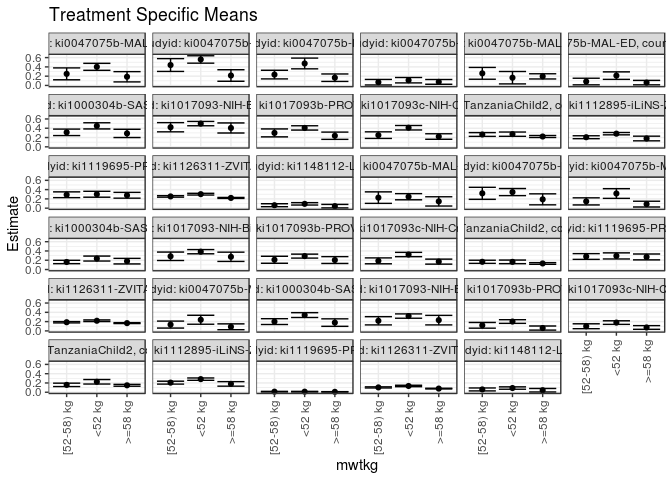

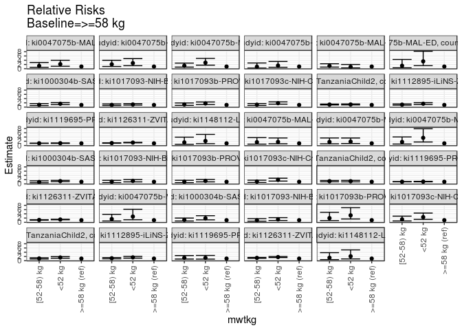

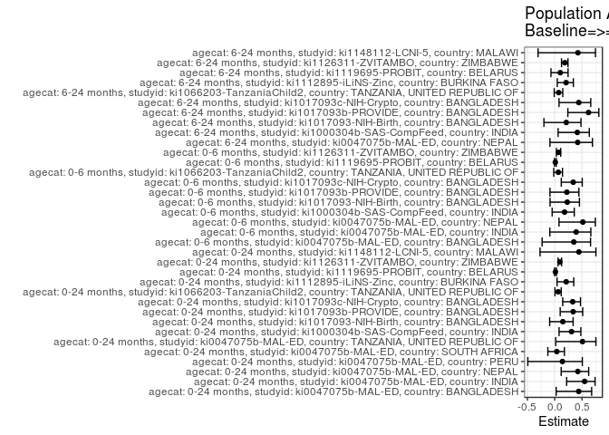

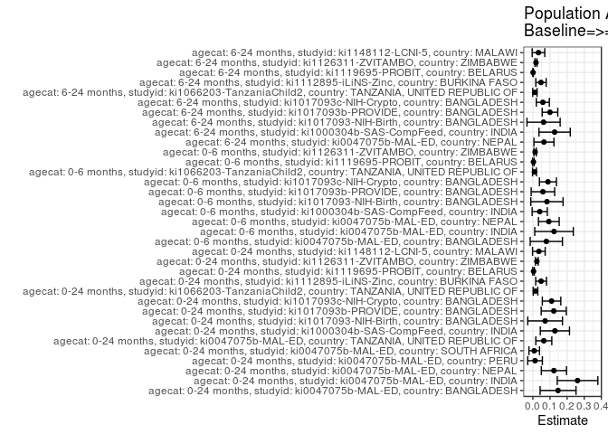

## Results Table

### Parameter: TSM

| agecat | studyid | country | intervention_level | baseline_level | estimate | ci_lower | ci_upper |
| --- | --- | --- | --- | --- | --- | --- | --- |
| 0-24 months | ki0047075b-MAL-ED | BANGLADESH | >=58 kg | NA | 0.1875000 | 0.0768640 | 0.2981360 |
| 0-24 months | ki0047075b-MAL-ED | BANGLADESH | <52 kg | NA | 0.4012346 | 0.3256079 | 0.4768612 |
| 0-24 months | ki0047075b-MAL-ED | BANGLADESH | [52-58) kg | NA | 0.2500000 | 0.1218027 | 0.3781973 |
| 0-24 months | ki0047075b-MAL-ED | INDIA | >=58 kg | NA | 0.2142857 | 0.0899341 | 0.3386374 |
| 0-24 months | ki0047075b-MAL-ED | INDIA | <52 kg | NA | 0.5600000 | 0.4803984 | 0.6396016 |
| 0-24 months | ki0047075b-MAL-ED | INDIA | [52-58) kg | NA | 0.4400000 | 0.3021259 | 0.5778741 |
| 0-24 months | ki0047075b-MAL-ED | NEPAL | >=58 kg | NA | 0.1670359 | 0.0870112 | 0.2470606 |
| 0-24 months | ki0047075b-MAL-ED | NEPAL | <52 kg | NA | 0.4737494 | 0.3578112 | 0.5896876 |
| 0-24 months | ki0047075b-MAL-ED | NEPAL | [52-58) kg | NA | 0.2341223 | 0.1407917 | 0.3274530 |
| 0-24 months | ki0047075b-MAL-ED | PERU | >=58 kg | NA | 0.0769231 | 0.0256217 | 0.1282244 |
| 0-24 months | ki0047075b-MAL-ED | PERU | <52 kg | NA | 0.1130435 | 0.0550708 | 0.1710161 |
| 0-24 months | ki0047075b-MAL-ED | PERU | [52-58) kg | NA | 0.0704225 | 0.0108059 | 0.1300392 |
| 0-24 months | ki0047075b-MAL-ED | SOUTH AFRICA | >=58 kg | NA | 0.1958763 | 0.1399256 | 0.2518270 |
| 0-24 months | ki0047075b-MAL-ED | SOUTH AFRICA | <52 kg | NA | 0.1666667 | 0.0330604 | 0.3002730 |
| 0-24 months | ki0047075b-MAL-ED | SOUTH AFRICA | [52-58) kg | NA | 0.2608696 | 0.1337398 | 0.3879993 |
| 0-24 months | ki0047075b-MAL-ED | TANZANIA, UNITED REPUBLIC OF | >=58 kg | NA | 0.0612245 | 0.0136660 | 0.1087830 |
| 0-24 months | ki0047075b-MAL-ED | TANZANIA, UNITED REPUBLIC OF | <52 kg | NA | 0.2121212 | 0.1314345 | 0.2928079 |
| 0-24 months | ki0047075b-MAL-ED | TANZANIA, UNITED REPUBLIC OF | [52-58) kg | NA | 0.0847458 | 0.0135422 | 0.1559493 |
| 0-24 months | ki1000304b-SAS-CompFeed | INDIA | >=58 kg | NA | 0.2888453 | 0.1997377 | 0.3779530 |
| 0-24 months | ki1000304b-SAS-CompFeed | INDIA | <52 kg | NA | 0.4518232 | 0.3853422 | 0.5183041 |
| 0-24 months | ki1000304b-SAS-CompFeed | INDIA | [52-58) kg | NA | 0.3120798 | 0.2422581 | 0.3819015 |
| 0-24 months | ki1017093-NIH-Birth | BANGLADESH | >=58 kg | NA | 0.4060954 | 0.2976583 | 0.5145325 |
| 0-24 months | ki1017093-NIH-Birth | BANGLADESH | <52 kg | NA | 0.5002723 | 0.4537337 | 0.5468108 |
| 0-24 months | ki1017093-NIH-Birth | BANGLADESH | [52-58) kg | NA | 0.4221517 | 0.3229578 | 0.5213456 |
| 0-24 months | ki1017093b-PROVIDE | BANGLADESH | >=58 kg | NA | 0.2383733 | 0.1599954 | 0.3167512 |
| 0-24 months | ki1017093b-PROVIDE | BANGLADESH | <52 kg | NA | 0.4072143 | 0.3607546 | 0.4536741 |
| 0-24 months | ki1017093b-PROVIDE | BANGLADESH | [52-58) kg | NA | 0.2997632 | 0.2142248 | 0.3853016 |
| 0-24 months | ki1017093c-NIH-Crypto | BANGLADESH | >=58 kg | NA | 0.2220111 | 0.1626273 | 0.2813949 |
| 0-24 months | ki1017093c-NIH-Crypto | BANGLADESH | <52 kg | NA | 0.4112515 | 0.3630138 | 0.4594893 |
| 0-24 months | ki1017093c-NIH-Crypto | BANGLADESH | [52-58) kg | NA | 0.2514622 | 0.1805364 | 0.3223880 |

[output cut: 75 more lines]

### Parameter: E(Y)

| agecat | studyid | country | intervention_level | baseline_level | estimate | ci_lower | ci_upper |
| --- | --- | --- | --- | --- | --- | --- | --- |
| 0-24 months | ki0047075b-MAL-ED | BANGLADESH | NA | NA | 0.3346457 | 0.2765014 | 0.3927899 |
| 0-24 months | ki0047075b-MAL-ED | INDIA | NA | NA | 0.4752066 | 0.4121581 | 0.5382551 |
| 0-24 months | ki0047075b-MAL-ED | NEPAL | NA | NA | 0.2899160 | 0.2321510 | 0.3476810 |
| 0-24 months | ki0047075b-MAL-ED | PERU | NA | NA | 0.0896552 | 0.0567177 | 0.1225926 |
| 0-24 months | ki0047075b-MAL-ED | SOUTH AFRICA | NA | NA | 0.2037037 | 0.1555745 | 0.2518329 |
| 0-24 months | ki0047075b-MAL-ED | TANZANIA, UNITED REPUBLIC OF | NA | NA | 0.1250000 | 0.0844083 | 0.1655917 |
| 0-24 months | ki1000304b-SAS-CompFeed | INDIA | NA | NA | 0.4175017 | 0.3589990 | 0.4760043 |
| 0-24 months | ki1017093-NIH-Birth | BANGLADESH | NA | NA | 0.4775641 | 0.4383415 | 0.5167867 |
| 0-24 months | ki1017093b-PROVIDE | BANGLADESH | NA | NA | 0.3602392 | 0.3238339 | 0.3966444 |
| 0-24 months | ki1017093c-NIH-Crypto | BANGLADESH | NA | NA | 0.3311258 | 0.2975342 | 0.3647175 |
| 0-24 months | ki1066203-TanzaniaChild2 | TANZANIA, UNITED REPUBLIC OF | NA | NA | 0.2372449 | 0.2200495 | 0.2544403 |
| 0-24 months | ki1112895-iLiNS-Zinc | BURKINA FASO | NA | NA | 0.2271869 | 0.2003867 | 0.2539871 |
| 0-24 months | ki1119695-PROBIT | BELARUS | NA | NA | 0.2816584 | 0.2197582 | 0.3435586 |
| 0-24 months | ki1126311-ZVITAMBO | ZIMBABWE | NA | NA | 0.2438216 | 0.2358577 | 0.2517856 |
| 0-24 months | ki1148112-LCNI-5 | MALAWI | NA | NA | 0.0787590 | 0.0605107 | 0.0970072 |
| 0-6 months | ki0047075b-MAL-ED | BANGLADESH | NA | NA | 0.2244094 | 0.1730022 | 0.2758167 |
| 0-6 months | ki0047075b-MAL-ED | INDIA | NA | NA | 0.3140496 | 0.2554513 | 0.3726479 |
| 0-6 months | ki0047075b-MAL-ED | NEPAL | NA | NA | 0.1806723 | 0.1316889 | 0.2296556 |
| 0-6 months | ki1000304b-SAS-CompFeed | INDIA | NA | NA | 0.2208054 | 0.1758216 | 0.2657892 |
| 0-6 months | ki1017093-NIH-Birth | BANGLADESH | NA | NA | 0.3569132 | 0.3192325 | 0.3945938 |
| 0-6 months | ki1017093b-PROVIDE | BANGLADESH | NA | NA | 0.2630792 | 0.2296894 | 0.2964690 |
| 0-6 months | ki1017093c-NIH-Crypto | BANGLADESH | NA | NA | 0.2582781 | 0.2270370 | 0.2895193 |
| 0-6 months | ki1066203-TanzaniaChild2 | TANZANIA, UNITED REPUBLIC OF | NA | NA | 0.1403061 | 0.1262673 | 0.1543450 |
| 0-6 months | ki1119695-PROBIT | BELARUS | NA | NA | 0.2746152 | 0.2119692 | 0.3372611 |
| 0-6 months | ki1126311-ZVITAMBO | ZIMBABWE | NA | NA | 0.1803706 | 0.1732226 | 0.1875186 |
| 6-24 months | ki0047075b-MAL-ED | NEPAL | NA | NA | 0.1531915 | 0.1070438 | 0.1993392 |
| 6-24 months | ki1000304b-SAS-CompFeed | INDIA | NA | NA | 0.3062998 | 0.2626026 | 0.3499970 |
| 6-24 months | ki1017093-NIH-Birth | BANGLADESH | NA | NA | 0.2939002 | 0.2554778 | 0.3323226 |
| 6-24 months | ki1017093b-PROVIDE | BANGLADESH | NA | NA | 0.1612378 | 0.1321259 | 0.1903497 |
| 6-24 months | ki1017093c-NIH-Crypto | BANGLADESH | NA | NA | 0.1315068 | 0.1069744 | 0.1560393 |
| 6-24 months | ki1066203-TanzaniaChild2 | TANZANIA, UNITED REPUBLIC OF | NA | NA | 0.1612740 | 0.1450620 | 0.1774860 |
| 6-24 months | ki1112895-iLiNS-Zinc | BURKINA FASO | NA | NA | 0.2271869 | 0.2003867 | 0.2539871 |
| 6-24 months | ki1119695-PROBIT | BELARUS | NA | NA | 0.0103168 | 0.0071373 | 0.0134962 |
| 6-24 months | ki1126311-ZVITAMBO | ZIMBABWE | NA | NA | 0.0973196 | 0.0914209 | 0.1032182 |
| 6-24 months | ki1148112-LCNI-5 | MALAWI | NA | NA | 0.0764563 | 0.0583018 | 0.0946108 |

### Parameter: RR

| agecat | studyid | country | intervention_level | baseline_level | estimate | ci_lower | ci_upper |
| --- | --- | --- | --- | --- | --- | --- | --- |
| 0-24 months | ki0047075b-MAL-ED | BANGLADESH | >=58 kg | >=58 kg | 1.0000000 | 1.0000000 | 1.000000 |
| 0-24 months | ki0047075b-MAL-ED | BANGLADESH | <52 kg | >=58 kg | 2.1399177 | 1.1518112 | 3.975693 |
| 0-24 months | ki0047075b-MAL-ED | BANGLADESH | [52-58) kg | >=58 kg | 1.3333333 | 0.6101437 | 2.913704 |
| 0-24 months | ki0047075b-MAL-ED | INDIA | >=58 kg | >=58 kg | 1.0000000 | 1.0000000 | 1.000000 |
| 0-24 months | ki0047075b-MAL-ED | INDIA | <52 kg | >=58 kg | 2.6133333 | 1.4378705 | 4.749740 |
| 0-24 months | ki0047075b-MAL-ED | INDIA | [52-58) kg | >=58 kg | 2.0533333 | 1.0617947 | 3.970803 |
| 0-24 months | ki0047075b-MAL-ED | NEPAL | >=58 kg | >=58 kg | 1.0000000 | 1.0000000 | 1.000000 |
| 0-24 months | ki0047075b-MAL-ED | NEPAL | <52 kg | >=58 kg | 2.8362130 | 1.6546856 | 4.861409 |
| 0-24 months | ki0047075b-MAL-ED | NEPAL | [52-58) kg | >=58 kg | 1.4016289 | 0.7506166 | 2.617266 |
| 0-24 months | ki0047075b-MAL-ED | PERU | >=58 kg | >=58 kg | 1.0000000 | 1.0000000 | 1.000000 |
| 0-24 months | ki0047075b-MAL-ED | PERU | <52 kg | >=58 kg | 1.4695652 | 0.6336052 | 3.408466 |
| 0-24 months | ki0047075b-MAL-ED | PERU | [52-58) kg | >=58 kg | 0.9154930 | 0.3116133 | 2.689640 |
| 0-24 months | ki0047075b-MAL-ED | SOUTH AFRICA | >=58 kg | >=58 kg | 1.0000000 | 1.0000000 | 1.000000 |
| 0-24 months | ki0047075b-MAL-ED | SOUTH AFRICA | <52 kg | >=58 kg | 0.8508772 | 0.3633111 | 1.992760 |
| 0-24 months | ki0047075b-MAL-ED | SOUTH AFRICA | [52-58) kg | >=58 kg | 1.3318078 | 0.7570416 | 2.342952 |
| 0-24 months | ki0047075b-MAL-ED | TANZANIA, UNITED REPUBLIC OF | >=58 kg | >=58 kg | 1.0000000 | 1.0000000 | 1.000000 |
| 0-24 months | ki0047075b-MAL-ED | TANZANIA, UNITED REPUBLIC OF | <52 kg | >=58 kg | 3.4646465 | 1.4589079 | 8.227918 |
| 0-24 months | ki0047075b-MAL-ED | TANZANIA, UNITED REPUBLIC OF | [52-58) kg | >=58 kg | 1.3841808 | 0.4408035 | 4.346509 |
| 0-24 months | ki1000304b-SAS-CompFeed | INDIA | >=58 kg | >=58 kg | 1.0000000 | 1.0000000 | 1.000000 |
| 0-24 months | ki1000304b-SAS-CompFeed | INDIA | <52 kg | >=58 kg | 1.5642391 | 1.1720497 | 2.087662 |
| 0-24 months | ki1000304b-SAS-CompFeed | INDIA | [52-58) kg | >=58 kg | 1.0804391 | 0.7103406 | 1.643365 |
| 0-24 months | ki1017093-NIH-Birth | BANGLADESH | >=58 kg | >=58 kg | 1.0000000 | 1.0000000 | 1.000000 |
| 0-24 months | ki1017093-NIH-Birth | BANGLADESH | <52 kg | >=58 kg | 1.2319081 | 0.9284700 | 1.634515 |
| 0-24 months | ki1017093-NIH-Birth | BANGLADESH | [52-58) kg | >=58 kg | 1.0395382 | 0.7284774 | 1.483422 |
| 0-24 months | ki1017093b-PROVIDE | BANGLADESH | >=58 kg | >=58 kg | 1.0000000 | 1.0000000 | 1.000000 |
| 0-24 months | ki1017093b-PROVIDE | BANGLADESH | <52 kg | >=58 kg | 1.7083054 | 1.2066284 | 2.418563 |
| 0-24 months | ki1017093b-PROVIDE | BANGLADESH | [52-58) kg | >=58 kg | 1.2575370 | 0.8144909 | 1.941580 |
| 0-24 months | ki1017093c-NIH-Crypto | BANGLADESH | >=58 kg | >=58 kg | 1.0000000 | 1.0000000 | 1.000000 |
| 0-24 months | ki1017093c-NIH-Crypto | BANGLADESH | <52 kg | >=58 kg | 1.8523918 | 1.3831495 | 2.480827 |
| 0-24 months | ki1017093c-NIH-Crypto | BANGLADESH | [52-58) kg | >=58 kg | 1.1326560 | 0.7678898 | 1.670695 |

[output cut: 75 more lines]

### Parameter: PAR

| agecat | studyid | country | intervention_level | baseline_level | estimate | ci_lower | ci_upper |
| --- | --- | --- | --- | --- | --- | --- | --- |
| 0-24 months | ki0047075b-MAL-ED | BANGLADESH | >=58 kg | NA | 0.1471457 | 0.0422895 | 0.2520018 |
| 0-24 months | ki0047075b-MAL-ED | INDIA | >=58 kg | NA | 0.2609209 | 0.1422996 | 0.3795422 |
| 0-24 months | ki0047075b-MAL-ED | NEPAL | >=58 kg | NA | 0.1228801 | 0.0492069 | 0.1965533 |
| 0-24 months | ki0047075b-MAL-ED | PERU | >=58 kg | NA | 0.0127321 | -0.0300353 | 0.0554995 |
| 0-24 months | ki0047075b-MAL-ED | SOUTH AFRICA | >=58 kg | NA | 0.0078274 | -0.0229668 | 0.0386217 |
| 0-24 months | ki0047075b-MAL-ED | TANZANIA, UNITED REPUBLIC OF | >=58 kg | NA | 0.0637755 | 0.0171086 | 0.1104424 |
| 0-24 months | ki1000304b-SAS-CompFeed | INDIA | >=58 kg | NA | 0.1286563 | 0.0433355 | 0.2139771 |
| 0-24 months | ki1017093-NIH-Birth | BANGLADESH | >=58 kg | NA | 0.0714687 | -0.0299609 | 0.1728982 |
| 0-24 months | ki1017093b-PROVIDE | BANGLADESH | >=58 kg | NA | 0.1218659 | 0.0484945 | 0.1952373 |
| 0-24 months | ki1017093c-NIH-Crypto | BANGLADESH | >=58 kg | NA | 0.1091147 | 0.0551606 | 0.1630688 |
| 0-24 months | ki1066203-TanzaniaChild2 | TANZANIA, UNITED REPUBLIC OF | >=58 kg | NA | 0.0152058 | 0.0016137 | 0.0287979 |
| 0-24 months | ki1112895-iLiNS-Zinc | BURKINA FASO | >=58 kg | NA | 0.0479306 | 0.0164435 | 0.0794176 |
| 0-24 months | ki1119695-PROBIT | BELARUS | >=58 kg | NA | 0.0038258 | -0.0006196 | 0.0082711 |
| 0-24 months | ki1126311-ZVITAMBO | ZIMBABWE | >=58 kg | NA | 0.0231543 | 0.0153209 | 0.0309878 |
| 0-24 months | ki1148112-LCNI-5 | MALAWI | >=58 kg | NA | 0.0348993 | -0.0020178 | 0.0718164 |
| 0-6 months | ki0047075b-MAL-ED | BANGLADESH | >=58 kg | NA | 0.0785761 | -0.0155963 | 0.1727486 |
| 0-6 months | ki0047075b-MAL-ED | INDIA | >=58 kg | NA | 0.1235734 | 0.0109686 | 0.2361782 |
| 0-6 months | ki0047075b-MAL-ED | NEPAL | >=58 kg | NA | 0.0931723 | 0.0326646 | 0.1536799 |
| 0-6 months | ki1000304b-SAS-CompFeed | INDIA | >=58 kg | NA | 0.0399388 | -0.0044079 | 0.0842854 |
| 0-6 months | ki1017093-NIH-Birth | BANGLADESH | >=58 kg | NA | 0.0821131 | -0.0121240 | 0.1763502 |
| 0-6 months | ki1017093b-PROVIDE | BANGLADESH | >=58 kg | NA | 0.0585532 | -0.0100973 | 0.1272037 |
| 0-6 months | ki1017093c-NIH-Crypto | BANGLADESH | >=58 kg | NA | 0.0878902 | 0.0383359 | 0.1374445 |
| 0-6 months | ki1066203-TanzaniaChild2 | TANZANIA, UNITED REPUBLIC OF | >=58 kg | NA | 0.0093184 | -0.0019568 | 0.0205936 |
| 0-6 months | ki1119695-PROBIT | BELARUS | >=58 kg | NA | 0.0031126 | -0.0013330 | 0.0075582 |
| 0-6 months | ki1126311-ZVITAMBO | ZIMBABWE | >=58 kg | NA | 0.0130370 | 0.0059457 | 0.0201283 |
| 6-24 months | ki0047075b-MAL-ED | NEPAL | >=58 kg | NA | 0.0645839 | 0.0060879 | 0.1230799 |
| 6-24 months | ki1000304b-SAS-CompFeed | INDIA | >=58 kg | NA | 0.1270829 | 0.0356740 | 0.2184918 |
| 6-24 months | ki1017093-NIH-Birth | BANGLADESH | >=58 kg | NA | 0.0623645 | -0.0345288 | 0.1592578 |
| 6-24 months | ki1017093b-PROVIDE | BANGLADESH | >=58 kg | NA | 0.0998343 | 0.0543326 | 0.1453359 |
| 6-24 months | ki1017093c-NIH-Crypto | BANGLADESH | >=58 kg | NA | 0.0580435 | 0.0200953 | 0.0959917 |
| 6-24 months | ki1066203-TanzaniaChild2 | TANZANIA, UNITED REPUBLIC OF | >=58 kg | NA | 0.0117581 | -0.0009211 | 0.0244373 |
| 6-24 months | ki1112895-iLiNS-Zinc | BURKINA FASO | >=58 kg | NA | 0.0473282 | 0.0170409 | 0.0776155 |
| 6-24 months | ki1119695-PROBIT | BELARUS | >=58 kg | NA | 0.0010524 | -0.0004755 | 0.0025803 |
| 6-24 months | ki1126311-ZVITAMBO | ZIMBABWE | >=58 kg | NA | 0.0181453 | 0.0123285 | 0.0239621 |
| 6-24 months | ki1148112-LCNI-5 | MALAWI | >=58 kg | NA | 0.0325967 | -0.0041856 | 0.0693789 |

### Parameter: PAF

| agecat | studyid | country | intervention_level | baseline_level | estimate | ci_lower | ci_upper |
| --- | --- | --- | --- | --- | --- | --- | --- |
| 0-24 months | ki0047075b-MAL-ED | BANGLADESH | >=58 kg | NA | 0.4397059 | 0.0269915 | 0.6773620 |
| 0-24 months | ki0047075b-MAL-ED | INDIA | >=58 kg | NA | 0.5490683 | 0.2190253 | 0.7396338 |
| 0-24 months | ki0047075b-MAL-ED | NEPAL | >=58 kg | NA | 0.4238472 | 0.1192039 | 0.6231227 |
| 0-24 months | ki0047075b-MAL-ED | PERU | >=58 kg | NA | 0.1420118 | -0.4918851 | 0.5065681 |
| 0-24 months | ki0047075b-MAL-ED | SOUTH AFRICA | >=58 kg | NA | 0.0384255 | -0.1251152 | 0.1781948 |
| 0-24 months | ki0047075b-MAL-ED | TANZANIA, UNITED REPUBLIC OF | >=58 kg | NA | 0.5102041 | 0.0189072 | 0.7554767 |
| 0-24 months | ki1000304b-SAS-CompFeed | INDIA | >=58 kg | NA | 0.3081577 | 0.0804639 | 0.4794703 |
| 0-24 months | ki1017093-NIH-Birth | BANGLADESH | >=58 kg | NA | 0.1496525 | -0.0919364 | 0.3377903 |
| 0-24 months | ki1017093b-PROVIDE | BANGLADESH | >=58 kg | NA | 0.3382916 | 0.1008146 | 0.5130504 |
| 0-24 months | ki1017093c-NIH-Crypto | BANGLADESH | >=58 kg | NA | 0.3295265 | 0.1467446 | 0.4731534 |
| 0-24 months | ki1066203-TanzaniaChild2 | TANZANIA, UNITED REPUBLIC OF | >=58 kg | NA | 0.0640934 | 0.0051017 | 0.1195872 |
| 0-24 months | ki1112895-iLiNS-Zinc | BURKINA FASO | >=58 kg | NA | 0.2109742 | 0.0431110 | 0.3493899 |
| 0-24 months | ki1119695-PROBIT | BELARUS | >=58 kg | NA | 0.0135829 | -0.0029336 | 0.0298275 |
| 0-24 months | ki1126311-ZVITAMBO | ZIMBABWE | >=58 kg | NA | 0.0949643 | 0.0623353 | 0.1264579 |
| 0-24 months | ki1148112-LCNI-5 | MALAWI | >=58 kg | NA | 0.4431153 | -0.2685075 | 0.7555233 |
| 0-6 months | ki0047075b-MAL-ED | BANGLADESH | >=58 kg | NA | 0.3501462 | -0.2304051 | 0.6567716 |
| 0-6 months | ki0047075b-MAL-ED | INDIA | >=58 kg | NA | 0.3934837 | -0.0893866 | 0.6623219 |
| 0-6 months | ki0047075b-MAL-ED | NEPAL | >=58 kg | NA | 0.5156977 | 0.0793411 | 0.7452382 |
| 0-6 months | ki1000304b-SAS-CompFeed | INDIA | >=58 kg | NA | 0.1808778 | -0.0464668 | 0.3588318 |
| 0-6 months | ki1017093-NIH-Birth | BANGLADESH | >=58 kg | NA | 0.2300646 | -0.0849036 | 0.4535916 |
| 0-6 months | ki1017093b-PROVIDE | BANGLADESH | >=58 kg | NA | 0.2225688 | -0.0863761 | 0.4436556 |
| 0-6 months | ki1017093c-NIH-Crypto | BANGLADESH | >=58 kg | NA | 0.3402928 | 0.1210867 | 0.5048276 |
| 0-6 months | ki1066203-TanzaniaChild2 | TANZANIA, UNITED REPUBLIC OF | >=58 kg | NA | 0.0664148 | -0.0172840 | 0.1432271 |
| 0-6 months | ki1119695-PROBIT | BELARUS | >=58 kg | NA | 0.0113344 | -0.0054622 | 0.0278504 |
| 0-6 months | ki1126311-ZVITAMBO | ZIMBABWE | >=58 kg | NA | 0.0722791 | 0.0321971 | 0.1107011 |
| 6-24 months | ki0047075b-MAL-ED | NEPAL | >=58 kg | NA | 0.4215893 | -0.0867215 | 0.6921392 |
| 6-24 months | ki1000304b-SAS-CompFeed | INDIA | >=58 kg | NA | 0.4148972 | 0.0626207 | 0.6347847 |
| 6-24 months | ki1017093-NIH-Birth | BANGLADESH | >=58 kg | NA | 0.2121962 | -0.1973383 | 0.4816546 |
| 6-24 months | ki1017093b-PROVIDE | BANGLADESH | >=58 kg | NA | 0.6191742 | 0.2410369 | 0.8089126 |
| 6-24 months | ki1017093c-NIH-Crypto | BANGLADESH | >=58 kg | NA | 0.4413724 | 0.0794650 | 0.6609963 |
| 6-24 months | ki1066203-TanzaniaChild2 | TANZANIA, UNITED REPUBLIC OF | >=58 kg | NA | 0.0729077 | -0.0089040 | 0.1480854 |
| 6-24 months | ki1112895-iLiNS-Zinc | BURKINA FASO | >=58 kg | NA | 0.2083227 | 0.0472197 | 0.3421852 |
| 6-24 months | ki1119695-PROBIT | BELARUS | >=58 kg | NA | 0.1020062 | -0.0682040 | 0.2450947 |
| 6-24 months | ki1126311-ZVITAMBO | ZIMBABWE | >=58 kg | NA | 0.1864506 | 0.1253726 | 0.2432633 |
| 6-24 months | ki1148112-LCNI-5 | MALAWI | >=58 kg | NA | 0.4263436 | -0.3046507 | 0.7477626 |